# DAR F22 Assignment 02

Fairness Auditor

Eric Song

09/14/2022

### Guide to linking to Shiny Apps

- On the cluster, create a sub-directory called `ShinyApps` in your home directory
  - In RStudio in the **Terminal** tab, `cd ~`
  - Then `mkdir ShinyApps`
  - You only need to do this once
- In your new `ShinyApps` sub-directory, create a sub-directory to contain your app
  - In the **Terminal** tab, `cd ~/ShinyApps`
  - Then `mkdir yourcoolapp` (if `yourcoolapp` is the name of your app)
  - Then copy all of the files associated with your app (esp. the `app.R`) in that directory
- Alternatively, you can create a symbolic link in that directory, “pointing” to your working directory. In this way your shared app will always be up-to-date.
  - In the **Terminal** tab, `cd ~/ShinyApps`
  - Then (for example) `ln -s /home/yourrcs/yourappdirectory yourcoolapp`
- You can now share your app on the RPI network using this syntax:
  - `http://lp01.idea.rpi.edu/shiny/yourrcs/yourcoolapp/`

## Weekly Work Summary

**NOTE:** Follow an outline format; use bullets to express individual points.

- RCS ID: **Always** include this!
- Project Name: **Always** include this!
- Summary of work since last week
  - Describe the important aspects of what you worked on and accomplished
- NEW: Summary of github issues added and worked
  - Issues that you’ve submitted
  - Issues that you’ve self-assigned and addressed
- Summary of github commits
  - include branch name(s)
  - include browsable links to all external files on github
  - Include links to shared Shiny apps
- List of presentations, papers, or other outputs
  - Include browsable links
- List of references (if necessary)
- Indicate any use of group shared code base
- Indicate which parts of your described work were done by you or as part of joint efforts

## Personal Contribution

- Clearly defined, unique contribution(s) done by you: code, ideas, writing…
- Include github issues you’ve addressed

## Discussion of Primary Findings

- Discuss primary findings:
  - What did you want to know?
  - How did you go about finding it?
  - What did you find?
- **Required:** Provide illustrating figures and/or tables
  - Embed your code in this notebook if possible.
  - If not possible, screen shots are acceptable.
  - If your figures are “live,” either include source code embedded in notebook or provide github location for their source scripts.
  - If your contributions included things that are not done in an R-notebook, (e.g. researching, writing, and coding in Python), you still need to do this status notebook in R. Describe what you did here and put any products that you created in github. If you are writing online documents (e.g. overleaf or google docs), you can include links to the documents in this notebook instead of actual text. ****

## Evaluating Bias Mitigation Algorithms

This notebook includes the steps to 1) Process the data before training a Machine Learning model 2) Split the data into train-test 3) Train a Machine Learning model (without bias mitigation) - BaselineModel 4) Evaluate the utility and fairness metrics of BaselineModel 5) Train a Machine Learning model with a bias mitigation algorithm (Reweighing) - ReweighingModel 6) Evaluate the utility and fairness metrics of this ReweighingModel 7) Compare the scores for the two models

### Load required libraries

We load the required libraries for this project.

### 1) Process data

Load the required dataset file. The dataset is the Adult Income dataset. We are predicting whether the outcome variable `income`, having two classes: (a) >50K or (b) <=50K. We use the protected attribute as `gender`. It has two values: (a) Female and (b) Male.

```r
# Read data
filename <- "../data_files/dataset.csv"
df <- read.csv(filename)

# Look at the top rows
head(df)
```

```
##   age workclass fnlwgt    education educational.num     marital.status
## 1  25   Private 226802         11th               7      Never-married
## 2  38   Private  89814      HS-grad               9 Married-civ-spouse
## 3  28 Local-gov 336951   Assoc-acdm              12 Married-civ-spouse
## 4  44   Private 160323 Some-college              10 Married-civ-spouse
## 5  18         ? 103497 Some-college              10      Never-married
## 6  34   Private 198693         10th               6      Never-married
##          occupation  relationship  race gender capital.gain capital.loss
## 1 Machine-op-inspct     Own-child Black   Male            0            0
## 2   Farming-fishing       Husband White   Male            0            0
## 3   Protective-serv       Husband White   Male            0            0
## 4 Machine-op-inspct       Husband Black   Male         7688            0
## 5                 ?     Own-child White Female            0            0
## 6     Other-service Not-in-family White   Male            0            0
##   hours.per.week native.country income
## 1             40  United-States  <=50K
## 2             50  United-States  <=50K
## 3             40  United-States   >50K
## 4             40  United-States   >50K
## 5             30  United-States  <=50K
## 6             30  United-States  <=50K
```

The data can be processed to make it suitable for training Machine Learning models such as removing rows with missing values, removing repeated columns etc.

```r
# Convert marital-status to simpler categories
# If marital.status is either never-married, divorced, separated, widowed or single,
# the assigned value is 0 else 1
df$marital.status <- ifelse((df$marital.status == "Never-married") |
                                        (df$marital.status == "Divorced") |
                                        (df$marital.status == "Separated") |
                                        (df$marital.status == "Widowed") |
                                        (df$marital.status == "Single"), 0, 1)

# Remove rows with missing values (denoted by ?)
df[df == '?'] <- NA
df <- na.omit(df)

# Convert categorical columns to numerical and then change to integer type
df$gender <- ifelse(df$gender == "Male", 1, 0)
df$income <- ifelse(df$income == ">50K", 1, 0)

# Drop extra columns not to be used for model training
df <- subset(df, select = -c(`education`, `age`, `hours.per.week`, `fnlwgt`,
                       `capital.gain`, `capital.loss`, `native.country`))

# One-hot encode categorical columns
df$workclass <- as.factor(df$workclass)
df$occupation <- as.factor(df$occupation)
df$relationship <- as.factor(df$relationship)
df$race <- as.factor(df$race)
df <- one_hot(as.data.table(df))

# Save processed data
saved_filename <- "../data_files/processed_dataset.csv"
write.csv(df, saved_filename, row.names = FALSE)
```

### 2) Split data into train-test

We begin by splitting the data into train-test split.

```r
# Set seed for reproducibility
set.seed(0)

# Split data into train-test
# 70% data to be used for training
# 30% data to be used for testing

# Get indices
training_size <- floor(0.7*nrow(df))
train_ind <- sample(seq_len(nrow(df)), size = training_size)

# Split data
names(df) <- make.names(names(df))
train.raw <- df[train_ind, ]
test.raw <- df[-train_ind, ]

# Scale train-test data
# except for income and gender
pp = preProcess(subset(train.raw, select = -c(`gender`, `income`)))
train.scale <- predict(pp, subset(train.raw, select = -c(`gender`, `income`)))
test.scale <- predict(pp, subset(test.raw, select = -c(`gender`, `income`)))

# Attach income and gender to scaled data
train.scale$income <- train.raw$income
test.scale$income <- test.raw$income
train.scale$gender <- train.raw$gender
test.scale$gender <- test.raw$gender
```

### 3) Train a ML model - BaselineModel

Once the data is split, we train a Logistic Regression model on the training data. `income` is used as the outcome variable.

```r
# Train a Logistic Regression model
baselineModel <- glm(income ~ ., data = train.scale, family = binomial)

# Get prediction on test data
baselineModel.prob <- predict(baselineModel, test.scale, type = 'response')
baselineModel.pred <- ifelse(baselineModel.prob > 0.5, 1, 0)
```

### 4) Evaluate utility and fairness metrics for BaselineModel

First, the utility is evaluated using Balanced Accuracy. Balanced Accuracy measures the accuracy for both classes of an outcome variable. We use the function `bacc()` to evaluate balanced accuracy.

```r
# Calculate Balanced Accuracy
baselineModel.bal_acc <- bacc(as.factor(test.scale$income), as.factor(baselineModel.pred))
```

Next, the fairness is evaluated for the given model. The fairness is evaluated for Gender protected attribute with two classes: Male and Female. We calculate Equalized Odds. Link: https://kozodoi.me/r/fairness/packages/2020/05/01/fairness-tutorial.html

```r
# Create a copy of the dataset for fairness evaluation
test2 <- test.scale
test2$prob <- baselineModel.prob
test2$income <- as.factor(test2$income)
test2$gender <- as.factor(test2$gender)

# Evaluate TPR difference
# NOTE: In the library `fairness`, Equalized Odds is defined as separation which is
# the TPR difference only. This is not the same Equalized Odds calculated here.
tpr_results <- equal_odds(data         = test2,
                     outcome      = 'income',
                     outcome_base = '0',
                     group        = 'gender',
                     probs        = 'prob',
                     cutoff       = 0.5,
                     base         = '0')
tpr_diff <- tpr_results$Metric[1] - tpr_results$Metric[4]

# Evaluate FPR difference
fpr_results <- fpr_parity(data         = test2,
                     outcome      = 'income',
                     outcome_base = '0',
                     group        = 'gender',
                     probs        = 'prob',
                     cutoff       = 0.5,
                     base         = '0')
fpr_diff <- fpr_results$Metric[1] - fpr_results$Metric[4]

# Evaluate Equalized Odds (EO)
# We define equalized odds as discussed in class
baselineModel.eo <- max(abs(tpr_diff), abs(fpr_diff))
```

### 5) Train ML model with Reweighing

We train a Logsitic Regression model similar to step 3 while also applying Reweighing bias mitigation algorithm.

```r
# Apply reweighing before model training
# Get weights during Reweighing
reweighing_weights <- reweight(train.scale$gender, train.scale$income)
```

```
##
## changing protected to factor
```

```r
# Train a Logistic Regression model
reweighingModel <- glm(income ~ ., data = train.scale, family = binomial, weights = reweighing_weights)
# Get prediction on test data
reweighingModel.prob <- predict(reweighingModel, test.scale, type = 'response')
reweighingModel.pred <- ifelse(reweighingModel.prob > 0.5, 1, 0)
```

### 6) Evaluate utility and fairness metrics for ReweighingModel

Similar to step 4, evaluate balanced accuracy and equalized odds.

```r
# Calculate Balanced Accuracy
reweighingModel.bal_acc <- bacc(as.factor(test.scale$income), as.factor(reweighingModel.pred))

# Create a copy of the dataset for fairness evaluation
test3 <- test.scale
test3$prob <- reweighingModel.prob
test3$income <- as.factor(test3$income)
test3$gender <- as.factor(test3$gender)

# Evaluate TPR difference
tpr_results <- equal_odds(data         = test3,
                     outcome      = 'income',
                     outcome_base = '0',
                     group        = 'gender',
                     probs        = 'prob',
                     cutoff       = 0.5,
                     base         = '0')
tpr_diff <- tpr_results$Metric[1] - tpr_results$Metric[4]

# Evaluate FPR difference
fpr_results <- fpr_parity(data         = test3,
                     outcome      = 'income',
                     outcome_base = '0',
                     group        = 'gender',
                     probs        = 'prob',
                     cutoff       = 0.5,
                     base         = '0')
fpr_diff <- fpr_results$Metric[1] - fpr_results$Metric[4]

# Evaluate Equalized Odds (EO)
reweighingModel.eo <- max(abs(tpr_diff), abs(fpr_diff))
```

### 7) Compare the scores for the two models

We compare the Balanced Accuracy and Equalized Odds scores.

```r
print("# Balanced Accuracy scores")
```

```
## [1] "# Balanced Accuracy scores"
```

```r
print(paste0("Baseline model: ", baselineModel.bal_acc))
```

```
## [1] "Baseline model: 0.731132055066914"
```

```r
print(paste0("Reweighing model: ", reweighingModel.bal_acc))
```

```
## [1] "Reweighing model: 0.71559050053529"
```

```r
print("# Equalized Odds scores")
```

```
## [1] "# Equalized Odds scores"
```

```r
print(paste0("Baseline model: ", baselineModel.eo))
```

```
## [1] "Baseline model: 0.174426399671302"
```

```r
print(paste0("Reweighing model: ", reweighingModel.eo))
```

```
## [1] "Reweighing model: 0.108108254222261"
```

*Finding:* As a higher Balanced Accuracy score is better, Baseline model has a better performance than the Reweighing. On the other hand, a lower Equalized Odds score is better, Reweighing model is better. A model with Equalized Odds less than or equal to 0.1 is considered to be fair. So, Reweighing model is very close to being fair.

## TODO

### 1) Train another ML model

TODO: Try to applying another classification Machine Learning model of your choice. Evaluate Balanced Accuracy and Equalized Odds on the generated model.

```r
if (!require("rpart")) {
  install.packages('rpart')
  library(rpart)
}
```

```r
if (!require("rpart.plot")) {
  install.packages('rpart.plot')
  library(rpart.plot)
}
decisionTreeModel <- rpart(income ~ ., data = train.scale, method = 'class', cp = 0.001)
decisionTreeModel
```

```
## n= 31655
##
## node), split, n, loss, yval, (yprob)
##       * denotes terminal node
##
##  1) root 31655 7860 0 (0.75169799 0.24830201)
##    2) marital.status< 0.03879019 16441 1081 0 (0.93424974 0.06575026) *
##    3) marital.status>=0.03879019 15214 6779 0 (0.55442356 0.44557644)
##      6) educational.num< 0.9270531 10658 3514 0 (0.67029461 0.32970539)
##       12) educational.num< -0.6382163 1713  210 0 (0.87740806 0.12259194) *
##       13) educational.num>=-0.6382163 8945 3304 0 (0.63063164 0.36936836)
##         26) occupation_Exec.managerial< 1.086034 7808 2671 0 (0.65791496 0.34208504) *
##         27) occupation_Exec.managerial>=1.086034 1137  504 1 (0.44327177 0.55672823)
##           54) workclass_Self.emp.not.inc>=1.503027 158   43 0 (0.72784810 0.27215190) *
##           55) workclass_Self.emp.not.inc< 1.503027 979  389 1 (0.39734423 0.60265577) *
##      7) educational.num>=0.9270531 4556 1291 1 (0.28336260 0.71663740) *
```

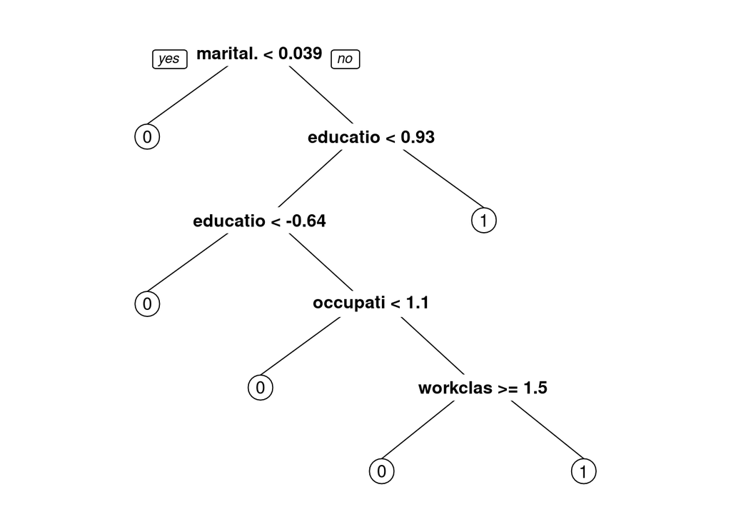

```r
prp(decisionTreeModel)
```

```r
decisionTreeModel.pred <-predict(decisionTreeModel, test.scale, type = 'class')

tableDecisionTree <- table(test.scale$income, decisionTreeModel.pred)
tableDecisionTree
```

```
##    decisionTreeModel.pred
##        0    1
##   0 9546  673
##   1 1757 1591
```

```r
decisionTreeModel.bal_acc <- bacc(as.factor(test.scale$income), as.factor(decisionTreeModel.pred))
decisionTreeModel.bal_acc
```

```
## [1] 0.7046757
```

```r
testDecisionTreeModel <- test.scale
testDecisionTreeModel$prob <- as.numeric(decisionTreeModel.pred)
testDecisionTreeModel$income <- as.factor(testDecisionTreeModel$income)
testDecisionTreeModel$gender <- as.factor(testDecisionTreeModel$gender)

tpr_results <- equal_odds(data    = testDecisionTreeModel,
                     outcome      = 'income',
                     outcome_base = '0',
                     group        = 'gender',
                     probs        = 'prob',
                     cutoff       = 0.5,
                     base         = '0')
tpr_diff <- tpr_results$Metric[1] - tpr_results$Metric[4]

fpr_results <- fpr_parity(data    = testDecisionTreeModel,
                     outcome      = 'income',
                     outcome_base = '0',
                     group        = 'gender',
                     probs        = 'prob',
                     cutoff       = 0.5,
                     base         = '0')
fpr_diff <- fpr_results$Metric[1] - fpr_results$Metric[4]

decisionTreeModel.eo <- max(abs(tpr_diff), abs(fpr_diff))
decisionTreeModel.eo
```

```
## [1] 0
```

### 2) Evaluate other fairness metrics

TODO: Identify two other fairness metrics apart from Equalized Odds and evaluate them on two ML models: BaselineModel and ReweighingModel.

Here’s resources for alternate metrics:

- https://kozodoi.me/r/fairness/packages/2020/05/01/fairness-tutorial.html
- https://github.com/Trusted-AI/AIF360/tree/master/aif360/aif360-r

The two fairness metrics I chose were specificity parity and ROC AUC parity. Both were found in the article by Nikita Kozodoi. Specificity parity is calculated by taking the ratio of true negatives to total negatives. ROC AUC parity takes the area under the ROC curve, which is the curve that tells you the relationship between specificity(true positive rate) and sensitivity(1 - false positive rate)

```r
testBaselineModel <- test.scale
testBaselineModel$prob <- baselineModel.prob
testBaselineModel$gender[testBaselineModel$gender == 1] <- "Male"
testBaselineModel$gender[testBaselineModel$gender == 0] <- "Female"
testBaselineModel$income <- as.factor(testBaselineModel$income)
testBaselineModel$gender <- as.factor(testBaselineModel$gender)

res_prop <- spec_parity(data      = testBaselineModel,
                     outcome      = 'income',
                     outcome_base = '0',
                     group        = 'gender',
                     probs        = 'prob',
                     cutoff       = 0.5,
                     base         = 'Female')
res_prop$Metric
```

```
##                          Female         Male
## Specificity           0.9799537    0.8925411
## Specificity Parity    1.0000000    0.9107992
## Group size         4415.0000000 9152.0000000
```

```r
res_auc <- roc_parity(data         = testBaselineModel,
                      outcome      = 'income',
                      group        = 'gender',
                      probs        = 'prob',
                      base         = 'Female')
res_auc$Metric
```

```
##                      Female         Male
## ROC AUC           0.8977664    0.8484981
## ROC AUC Parity    1.0000000    0.9451212
## Group size     4415.0000000 9152.0000000
```

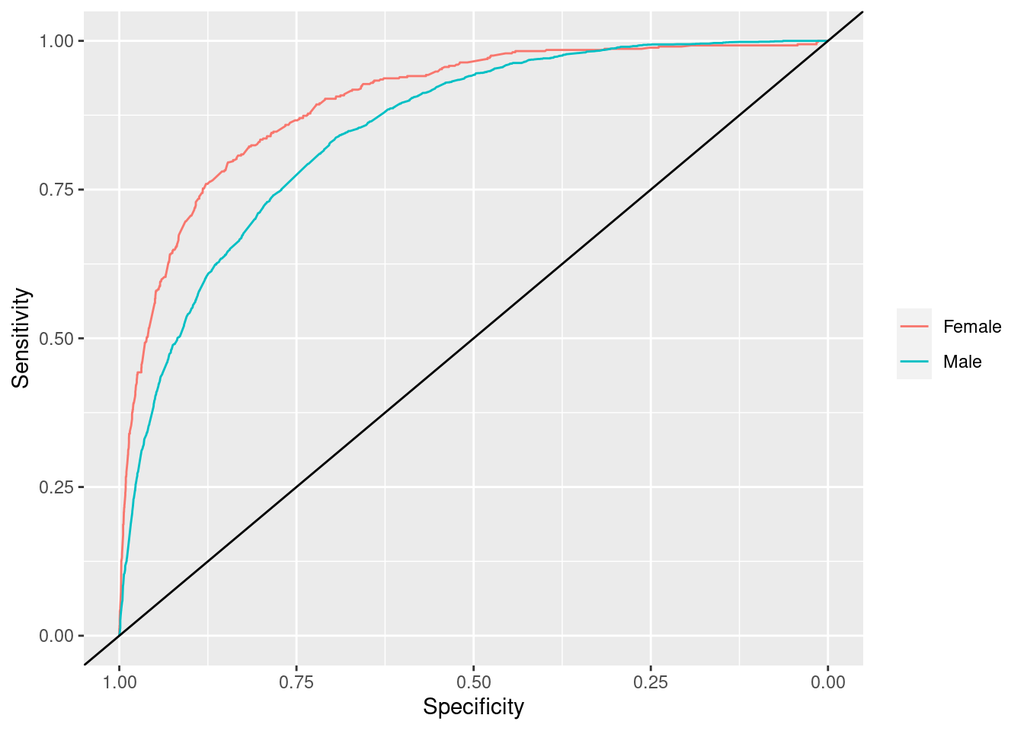

```r
res_auc$ROCAUC_plot
```

*Finding:* Evaluating the baseline model with these methods, we see that specificity parity gives us a very high specificity value for females of nearly 0.98, but a much lower value for males of around 0.89. This gives us specificity parity value of 0.91. Looking at our ROC curve, we immediately see a higher accuracy for females as an “ideal” ROC curve is a curve that goes straight up to the top left then to the top right. Thus, the area under the ROC curve is higher for females at around 0.90 compared to males at around 0.85. Our ROC parity value is then around 0.94-0.95.

```r
testReweighingModel <- test.scale
testReweighingModel$prob <- reweighingModel.prob
testReweighingModel$gender[testReweighingModel$gender == 1] <- "Male"
testReweighingModel$gender[testReweighingModel$gender == 0] <- "Female"
testReweighingModel$income <- as.factor(testReweighingModel$income)
testReweighingModel$gender <- as.factor(testReweighingModel$gender)

res_prop <- spec_parity(data      = testReweighingModel,
                     outcome      = 'income',
                     outcome_base = '0',
                     group        = 'gender',
                     probs        = 'prob',
                     cutoff       = 0.5,
                     base         = 'Female')
res_prop$Metric
```

```
##                          Female         Male
## Specificity           0.9442303    0.9255689
## Specificity Parity    1.0000000    0.9802364
## Group size         4415.0000000 9152.0000000
```

```r
res_auc <- roc_parity(data         = testReweighingModel,
                      outcome      = 'income',
                      group        = 'gender',
                      probs        = 'prob',
                      base         = 'Female')
res_auc$Metric
```

```
##                      Female         Male
## ROC AUC           0.8987767    0.8482999
## ROC AUC Parity    1.0000000    0.9438383
## Group size     4415.0000000 9152.0000000
```

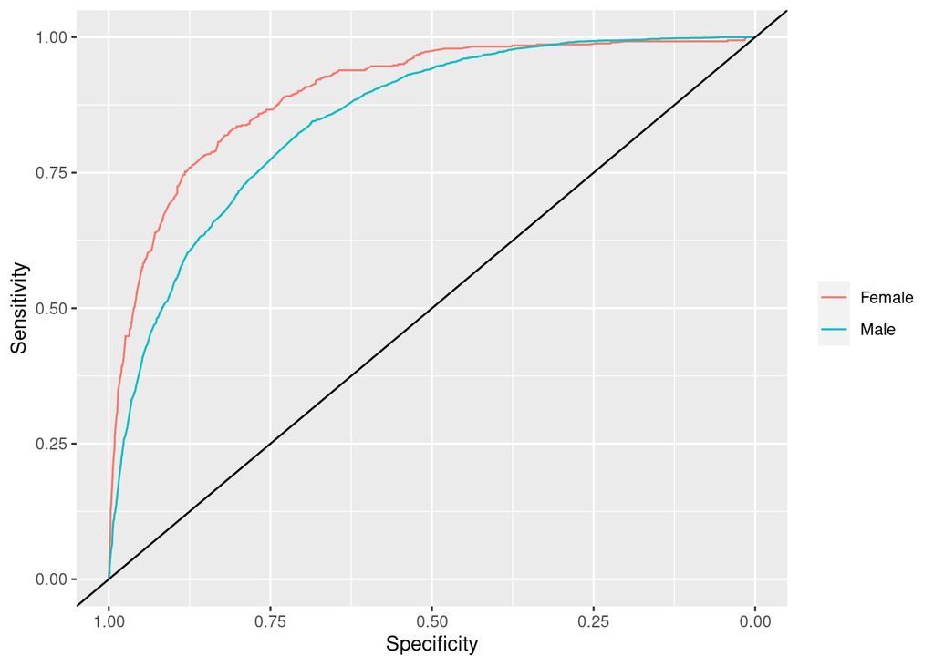

```r
res_auc$ROCAUC_plot
```

### 3) List fairness libraries

TODO: Find a list of libraries in R that include fairness metrics/methods or mitigation techniques. Keywords to look for: fairness, bias, bias mitigation, fairness mitigation. Make a summary of what you find.

*Finding:* I found documentation for several packages and libraries in R, both ones we have talked about and used such as fairmodels and ones we havent:

fairmodels: https://cran.r-project.org/web/packages/fairmodels/fairmodels.pdf

Fairmodels is the package that we use in this assignment for our bias mitigation algorithms. This package contains many more bias mitigation techniques, as well as says to visualize with plots. The goal of the model is to reduce discrimination in ml models.

aif360: https://aif360.readthedocs.io/en/latest/modules/algorithms.html

Aif360, or AI Fairness 360, is an open source toolkit to reduce bias. It includes generic, individual, and group fairness metrics, all with the goal to detect and mitigate bias in r.

enrichwith/brglm: https://cran.r-project.org/web/packages/enrichwith/vignettes/bias.html

Brglm is an r package and function that “estimates binomial-response GLMs using iterative ML fits on binomial pseudo-data” where GLM is generalized linear model and ML is maximum likelihood. This is only helpful for generalized linear models, but it is a way to reduce bias, even when the maximum likelihood is calculated as infinite.

### 4) Be prepared to discuss your findings in class (2-3 minutes)